# Time Series Data Analytics and Visualisation App’s Codes Report

```r
# Step 2d. Boruta Method

# In this case, we will use pv_values as a response variable and the remaining variables as an explanatory variable with the maxRuns argument of 25 (Use randomly sampled 10000 observations from the big dataset)

# Step 2d.1. Set Seed
set.seed(8)

# Step 2d.2. Fitting the model and calculate the variable importance
boruta_output <- Boruta(pv_values ~ ., data=mini_selection_df, doTrace=2, maxRuns=25)  # perform Boruta search
```

```r
# Step 2d.3. Print the boruta_output
boruta_output
# Boruta performed 24 iterations in 4.17909 mins.
#  14 attributes confirmed important: AirTemp, AlbedoDaily, Azimuth, Dhi,
# Dni and 9 more;
#  No attributes deemed unimportant.
#  1 tentative attributes left: CloudOpacity;
```

```r
# Step 2d.4. Collect Confirmed variables (i.e., confirmed that it is important by Boruta Algorithm)
boruta_signif <- names(boruta_output$finalDecision[boruta_output$finalDecision %in% c("Confirmed")])  # collect Confirmed variables

# Print the confirmed variables
boruta_signif
#  [1] "pv_values_1"       "AirTemp"           "Azimuth"
#  [4] "Dhi"               "Dni"               "Ebh"
#  [7] "Ghi"               "GtiFixedTilt"      "GtiTracking"
# [10] "PrecipitableWater" "RelativeHumidity"  "SurfacePressure"
# [13] "Zenith"            "AlbedoDaily"
```

```r
# Step 2d.5. Print the estimations of variable importance
boruta_output[["ImpHistory"]]
#       pv_values_1  AirTemp   Azimuth CloudOpacity      Dhi      Dni      Ebh
#  [1,]    60.45790 7.421973  8.763115     2.619944 5.347587 5.754684 5.608979
#  [2,]    58.94595 7.008671  8.670065     2.550888 5.499068 6.282261 5.403595
#  [3,]    60.06421 6.073126 10.211684     4.501518 5.383929 4.517439 5.896726
#  [4,]    60.90956 7.474263  8.824279     3.053202 6.478025 4.886740 6.283435
#  [5,]    58.39343 9.820483  9.506964     1.999066 5.589915 4.262195 3.393182
#  [6,]    58.73811 7.215758  6.479976     2.127391 4.741850 5.061508 4.949310
#  [7,]    61.61609 8.558319  9.753123     2.107687 6.201697 6.469412 3.344498
#  [8,]    58.30175 8.346826  8.273127     3.818149 6.398128 5.447812 4.003404
#  [9,]    62.63481 7.411492  9.426833     3.895003 5.468288 6.125061 5.120650
# [10,]    60.23016 7.274754  9.907748     3.924202 4.317500 6.012974 4.337578
# [11,]    61.37676 7.577989  9.359536     1.847356 5.092132 4.904404 3.552741
# [12,]    61.29067 7.828839  9.195741     3.543975 5.377029 6.528962 6.209997
# [13,]    58.69902 8.923223  8.934747     3.016966 6.565920 5.829668 4.074455
# [14,]    57.60443 8.009904  7.552572     3.372934 6.729491 5.339445 6.048479
# [15,]    61.46816 8.827059  7.380879     3.367130 4.224117 5.550067 4.104218
# [16,]    59.07544 7.440335  9.263282     1.908626 3.960792 5.042688 5.107583
# [17,]    61.42900 8.637604  7.870565     1.128373 6.384793 4.990924 4.823362
# [18,]    63.12563 7.107620  7.162357     3.599949 3.977807 3.588101 5.739916
# [19,]    61.13483 7.925770  8.937695     3.780786 4.658420 5.034304 6.195823
# [20,]    63.48243 6.173813  8.495142     3.436912 4.795846 5.125977 4.752302
# [21,]    56.77363 8.338906  7.667290     3.343445 5.033985 5.199762 3.931592
# [22,]    57.93971 7.132759  8.215625     2.802967 5.915152 5.729722 4.048654
# [23,]    59.90625 8.415652 10.367764     3.192657 6.968711 4.538036 4.901988
# [24,]    57.61697 6.298465  8.186378     2.804663 5.248366 4.322393 5.049298
#            Ghi GtiFixedTilt GtiTracking PrecipitableWater RelativeHumidity
#  [1,] 7.540350     7.158012    4.528333          5.696129         5.812299
#  [2,] 6.018234     6.891665    4.043200          4.632721         5.918254
#  [3,] 7.014380     6.676729    5.256466          4.722969         7.034985
#  [4,] 6.767940     6.428559    6.016869          5.008947         6.417032
#  [5,] 5.946347     5.443435    4.716972          6.478396         6.843928
#  [6,] 4.608336     7.527528    5.500858          6.146513         6.228220
#  [7,] 5.293401     6.753047    4.006881          4.760584         6.040709
#  [8,] 3.200298     6.496868    3.240284          6.824922         6.462041
#  [9,] 5.567808     6.034559    4.996087          6.633253         7.819421
# [10,] 6.553257     7.064401    4.421637          5.361236         6.484125
# [11,] 4.913818     7.519835    4.060324          5.260654         6.053392
# [12,] 6.642176     4.381480    5.191021          6.228112         7.412828
# [13,] 6.422854     4.553757    3.416526          6.262788         4.741237
# [14,] 4.334146     7.279032    3.930234          5.989171         7.056371
# [15,] 5.167605     7.655288    3.645030          6.182854         6.330087
# [16,] 6.368949     5.594617    4.739893          4.618747         7.703954
# [17,] 5.105678     6.564287    5.252815          5.731916         5.325890
# [18,] 4.923964     5.957633    4.344166          6.336927         7.284552
# [19,] 7.442316     6.371617    5.149096          5.998166         6.037171
# [20,] 4.416040     5.530328    7.263123          5.043894         5.797464
# [21,] 5.284409     6.964638    4.805073          5.772964         8.696001
# [22,] 5.310094     6.119283    6.422149          5.258537         6.995794
# [23,] 6.229346     7.456329    4.601792          6.089377         5.585774
# [24,] 7.560453     6.121496    5.121936          4.938713         5.572288
#       SurfacePressure   Zenith AlbedoDaily shadowMax  shadowMean shadowMin
#  [1,]        4.551654 6.199682    4.586707 2.6664510  0.00599952 -2.467885
#  [2,]        3.102466 8.617680    5.157243 1.2305390  0.25347348 -1.379946
#  [3,]        3.519393 9.225120    2.821165 1.3343212 -0.60522668 -2.367015
#  [4,]        3.513479 7.362351    4.185804 2.1247030 -0.30556461 -2.016736
#  [5,]        4.073422 6.123156    4.828020 1.3279123 -0.29717001 -1.954058
#  [6,]        3.063098 7.091784    2.916816 1.4621378 -0.02976388 -1.706540
#  [7,]        3.527310 5.023338    3.341423 1.9510666  0.19271756 -1.860682
#  [8,]        4.630437 7.009804    2.857621 0.9195887 -0.68495537 -2.862932
#  [9,]        4.568998 8.800757    3.527873 2.2062848  0.40175674 -1.225707
# [10,]        2.882445 8.300895    2.769833 1.4320517 -0.24629535 -2.760109
# [11,]        4.665265 7.187129    3.545347 2.1191598  0.03981536 -1.548225
# [12,]        4.465061 5.472903    2.700518 2.4082502  0.36539145 -2.616985
# [13,]        4.475910 8.339516    3.999937 3.1511390  0.11782327 -2.085855
# [14,]        3.356819 7.000637    3.714290 1.6559765 -0.16283579 -1.834858
# [15,]        3.776188 9.323609    3.749709 0.7224883 -0.78010631 -2.480495
# [16,]        4.410138 8.170816    2.590428 1.3284710 -0.11508229 -3.525747
# [17,]        3.738984 8.154379    4.079710 1.2387870 -0.25430028 -1.682473
# [18,]        4.912665 6.904751    3.550055 2.1373570  0.60172919 -2.047381
# [19,]        5.170147 7.501341    4.707021 3.5574166  0.47845273 -1.314131
# [20,]        3.661388 7.536303    3.435083 2.2046793  0.18742984 -1.631002
# [21,]        4.254783 8.877861    1.715070 1.8695134 -0.47738342 -2.004052
# [22,]        5.030575 6.724124    3.336013 1.9486482 -0.17361700 -2.057782
# [23,]        3.970908 7.422588    2.854871 4.2746474 -0.27946324 -2.344788
# [24,]        3.845591 6.984836    3.851003 1.3676940 -0.36556302 -2.389367
```

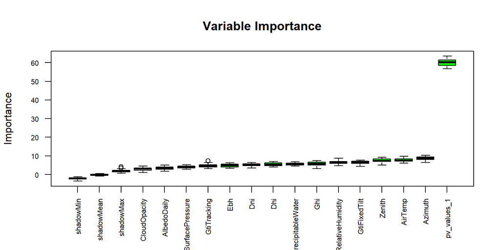

```r
# Step 2d.5. Plotting the variable importance
plot(boruta_output, cex.axis=.7, las=2, xlab="", main="Variable Importance")  # plot variable importance
```

### **Trend Codes for Filtering and Plot Parts (i.e., Server environment)**

**(RShiny App Lines: 3386 - 3435)**

This section will cover all the codes in the server environment for the Trend Page. To simplify the codes’ report, in this example, the inputs for each element in the Trend Page are as follow:

1. Set LV_North_Pavilion.MSB_PV_DB from 2020-07-01 to 2021-07-16 in the main filter (i.e., blue gear icon).

```r
# Trend
# (RShiny App Lines: 3386 - 3435)

# (In this example, we will be using LV_North_Pavilion.MSB_PV_DB from 2020-07-01 to 2021-07-16)

# Step 1. Create trend_df -> the subset of pv dataset after filtered by date and variable
trend_df <- pv %>%
  filter(between(PVdate, as.Date('2020-07-01'), as.Date('2021-07-16'))) %>% # filter Date
  dplyr::select(c(ReadTime, LV_North_Pavilion.MSB_PV_DB)) %>% # filter column
  na.omit() # remove NAs
```

```r
# Step 2. Change the trend_df into time series (ts) object

# Step 2a. Convert ReadTime into datetime data type by using Lubridate package
trenddatetime_df <- trend_df
trenddatetime_df$ReadTime <- dmy_hm(trenddatetime_df$ReadTime) #try dmy_hms

# Step 2b. Convert dataframe to time series
tseries <- read.zoo(trenddatetime_df)

# Step 2c. Convert to ts object
tseries_ts <- ts(tseries, frequency = 96)
```

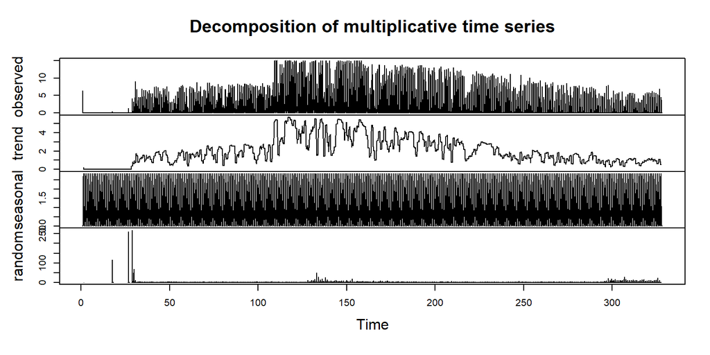

```r
# Step 3. Decompose the trend
decomposed_tseries_ts <- decompose(tseries_ts,type='multiplicative')

# Step 4. Plotting
plot(decomposed_tseries_ts)
```

## Bibliography

- Chang, Winston, Cheng, J., Allaire, J.J., Xie, Y., and McPherson, J. (2022, December 15). *Shiny: Web Application Framework for R*. https://CRAN.R-project.org/package=shiny
- Kassambara. (2017, November 17). *Plot time series data using GGplot*. STHDA. http://www.sthda.com/english/articles/32-r-graphics-essentials/128-plot-time-series-data-using-ggplot/
- Laufer, J. (2019, February 5). *Missing value visualization with tidyverse in R*. https://jenslaufer.com/data/analysis/visualize_missing_values_with_ggplot.html
- Marriane. (2021, September 30). *9 principles of good web design*. Feeling Peaky. https://www.feelingpeaky.com/9-principles-of-good-web-design/
- Nikola, O. (2021, December 29). *Random Forest Regression in R: Code and Interpretation*. Feeling Peaky. https://hackernoon.com/random-forest-regression-in-r-code-and-interpretation
- sgr308. (2022, July 22). *how to see second tabitem after clicking action button??* Posit Community. https://community.rstudio.com/t/how-to-see-second-tabitem-after-clicking-action-button/142783
- Tierney, N. (2023, February 2). *Getting started with naniar*. https://cran.r-project.org/web/packages/naniar/vignettes/getting-started-w-naniar.html